# De Silva_HW6

Sindupa De Silva

April 5, 2021

Included in this homework is an example N-mixture modeling dataset:

**count.csv**: Counts from each replicate survey. Each row is a site, and each column is a replicate survey. Column names j1, j2, j3 represent each replicate survey.

**obs_covs.csv**: A continuous covariate associated with each replicate survey. Each row is a site, and each column is a replicate survey. Column names j1, j2, j3 represent each replicate survey.

**site_covs.csv**: Covariates associated with each site. Each row is a site, and each column a covariate. Column x1 is a continuous covariate, and column x2 is a categorical covariate with 4 levels: "a", "b", "c", and "d".

1. Load data and place into an unmarkedFramePCount object

```r
library(unmarked)
# Import data
count <- read.csv('count.csv') # detection/ non-detection
obs_covs <- read.csv('obs_covs.csv') # detection covariate
site_covs <- read.csv('site_covs.csv') # site-level covariate

# Create a matrix of detection/ non-detection
count_mat <- as.matrix(count)

# Create a list of detection covariates
obs_covs_list <- list(j = obs_covs)

# Place the data into an unmarkedFrameOccu object
nmix_data <- unmarkedFramePCount(y = count_mat, # detection / non-detection
                                 siteCovs = site_covs, # site-level covariate
                                 obsCovs = obs_covs_list) # detection covariate
```

2. Fit an N-mixture model that assumes conditional detection probability is a function of the detection covariate provided, and expected abundance is a additive function of variables x1 and x2.

```r
# Occupancy model for conditional detection probability
Fit_nmix <- pcount(~ j ~ x1 + x2, data = nmix_data, K = 100)
summary(Fit_nmix)
```

```
##
## Call:
## pcount(formula = ~j ~ x1 + x2, data = nmix_data, K = 100)
##
## Abundance (log-scale):
##             Estimate     SE     z  P(>|z|)
## (Intercept)    0.915 0.1106  8.27 1.30e-16
## x1             0.370 0.0401  9.21 3.14e-20
## x2b           -0.161 0.1382 -1.16 2.45e-01
## x2c           -0.189 0.1522 -1.24 2.14e-01
## x2d            1.335 0.1195 11.17 5.63e-29
##
## Detection (logit-scale):
##             Estimate     SE     z  P(>|z|)
## (Intercept)    1.259 0.0925  13.6 4.01e-42
## j             -0.841 0.0639 -13.2 1.57e-39
##
## AIC: 1736.028
## Number of sites: 200
## optim convergence code: 0
## optim iterations: 46
## Bootstrap iterations: 0
```

3. Interpret the effect of x1 on the expected count at each site. Verity your interpretation in R.

```r
# Extract the coefficients
betas <- coef(Fit_nmix)
betas
```

```
##   lam(Int)    lam(x1)   lam(x2b)   lam(x2c)   lam(x2d)     p(Int)       p(j)
##  0.9151447  0.3696188 -0.1606306 -0.1891303  1.3351914  1.2585992 -0.8410807
```

```r
# x1 * 1, with all other covariates unchanged
x1A <- betas[1] + betas[2] * 1 + betas[3] + betas[4] + betas[5] + betas[6] + betas[7]

# x1 * 2, with all other covariates unchanged
x1B <- betas[1] + betas[2] * 2 + betas[3] + betas[4] + betas[5] + betas[6] + betas[7]

# B - A
x1B - x1A
```

```
##  lam(Int)
## 0.3696188
```

```r
# Compare to x1
betas[2]
```

```
##   lam(x1)
## 0.3696188
```

- For every 1-unit change in x1, it has an effect of 0.3696 on the log abundance of expected count at each site.
4. Predict and plot the effect of the supplied detection covariate. Do this over the range of this covariate.

```r
# New data frame of effect of the detection covariate
new_obs <- data.frame(j = seq(from = min(obs_covs),
           to = max(obs_covs), length.out = 200))

# Predicting the effect of the detection covariate
pred <- predict(object = Fit_nmix, newdata = new_obs, type = 'det')

# Checking the predictions
plogis(betas[6] + betas[7] * min(obs_covs)) ; pred [1,1] # min
```

```
##    p(Int)
## 0.9698079
```

```
## [1] 0.9698079
```

```r
plogis(betas[6] + betas[7] * max(obs_covs)) ; pred [200,1] # max
```

```
##    p(Int)
## 0.1707027
```

```
## [1] 0.1707027
```

```r
# 95% confidence intervals
obs_covs_low <- pred$Predicted - qnorm(0.975) * pred$SE # low
head(obs_covs_low)
```

```
## [1] 0.9563772 0.9554086 0.9544197 0.9534101 0.9523794 0.9513273
```

```r
obs_covs_high <- pred$Predicted + qnorm(0.975) * pred$SE # high
head(obs_covs_high)
```

```
## [1] 0.9832386 0.9827032 0.9821519 0.9815842 0.9809998 0.9803981
```

```r
# Check with calculated values
pred[1,3] ; obs_covs_low[1]
```

```
## [1] 0.9530609
```

```
## [1] 0.9563772
```

```r
pred[200,3] ; obs_covs_low[200]
```

```
## [1] 0.1265685
```

```
## [1] 0.1210153
```

```r
pred[1,4] ; obs_covs_high[1]
```

```
## [1] 0.9807009
```

```
## [1] 0.9832386
```

```r
pred[200,4] ; obs_covs_high[200]
```

```
## [1] 0.2262402
```

```
## [1] 0.2203902
```

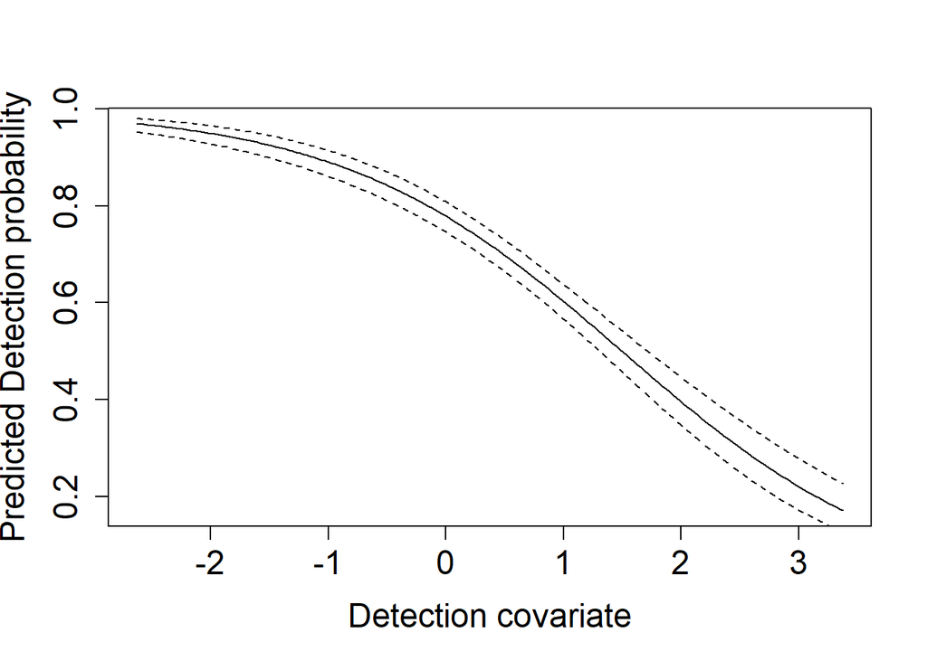

```r
# Plot the predicted results with confidence intervals
plot(x = new_obs$j, y = pred$Predicted, ylab = 'Predicted Detection probability',  xlab = 'Detection covariate', cex.axis = 1.5, cex.lab = 1.5, type = 'l')
lines(y = pred$lower, x = new_obs$j, lty = 2)
lines(y = pred$upper, x = new_obs$j, lty = 2)
```

5. Use contrasts to compare expected abundance between all pairwise levels of variable x2. Obtain p-values associated with each contrast and tell me whether you reject or fail to reject each null hypothesis tested.

```r
# Evaluate the beta coefficients to determine the pairwise levels of x2
betas
```

```
##   lam(Int)    lam(x1)   lam(x2b)   lam(x2c)   lam(x2d)     p(Int)       p(j)
##  0.9151447  0.3696188 -0.1606306 -0.1891303  1.3351914  1.2585992 -0.8410807
```

```r
# Create a contrast matrix to compare differences between x2 levels: B, C and D
x <- matrix(
  c(0, 0, -1, 1, 0,
    0, 0, -1, 0, 1,
    0, 0, 0, -1, 1),
  nrow = 3, byrow = T)

# Input the contrast matrix to unmarked
lin_com <- linearComb(obj = Fit_nmix, coefficients = x, type = 'state')
lin_com
```

```
## Linear combination(s) of Abundance estimate(s)
##
##   Estimate     SE (Intercept) x1 x2b x2c x2d
## 1  -0.0285 0.1332           0  0  -1   1   0
## 2   1.4958 0.0935           0  0  -1   0   1
## 3   1.5243 0.1140           0  0   0  -1   1
```

```r
# Perform a Wald test/ Test-statistic
Wald <- coef(lin_com) / SE(lin_com)
Wald
```

```
## [1] -0.2140043 15.9929898 13.3713082
```

```r
# Calculating the p-values for each null hypothesis test
2 * pnorm(-1 * abs(Wald))
```

```
## [1] 8.305437e-01 1.430000e-57 8.896230e-41
```

- Based on the derived p-values:
- We fail to reject the null hypothesis for the effect between x2 levels 'B' and 'C'. p-value > 0.05
- We reject the null hypothesis for the effect between x2 levels 'B' and 'D'. p-value < 0.05
- We reject the null hypothesis for the effect between x2 levels 'C' and 'D'. p-value < 0.05